# Example: Smoking cessation

```r
library(multinma)
options(mc.cores = parallel::detectCores())
```

This vignette describes the analysis of smoking cessation data (Hasselblad 1998), replicating the analysis in NICE Technical Support Document 4 (Dias et al. 2011). The data are available in this package as `smoking`:

```r
head(smoking)
```

```
#>   studyn trtn                   trtc  r   n
#> 1      1    1        No intervention  9 140
#> 2      1    3 Individual counselling 23 140
#> 3      1    4      Group counselling 10 138
#> 4      2    2              Self-help 11  78
#> 5      2    3 Individual counselling 12  85
#> 6      2    4      Group counselling 29 170
```

### Setting up the network

We begin by setting up the network. We have arm-level count data giving the number quitting smoking (`r`) out of the total (`n`) in each arm, so we use the function `set_agd_arm()`. Treatment “No intervention” is set as the network reference treatment.

```r
smknet <- set_agd_arm(smoking,
                      study = studyn,
                      trt = trtc,
                      r = r,
                      n = n,
                      trt_ref = "No intervention")
smknet
```

```
#> A network with 24 AgD studies (arm-based).
#>
#> ------------------------------------------------------- AgD studies (arm-based) ----
#>  Study Treatments
#>  1     3: No intervention | Individual counselling | Group counselling
#>  2     3: Self-help | Individual counselling | Group counselling
#>  3     2: No intervention | Individual counselling
#>  4     2: No intervention | Individual counselling
#>  5     2: No intervention | Individual counselling
#>  6     2: No intervention | Individual counselling
#>  7     2: No intervention | Individual counselling
#>  8     2: No intervention | Individual counselling
#>  9     2: No intervention | Individual counselling
#>  10    2: No intervention | Self-help
#>  ... plus 14 more studies
#>
#>  Outcome type: count
#> ------------------------------------------------------------------------------------
#> Total number of treatments: 4
#> Total number of studies: 24
#> Reference treatment is: No intervention
#> Network is connected
```

Plot the network structure.

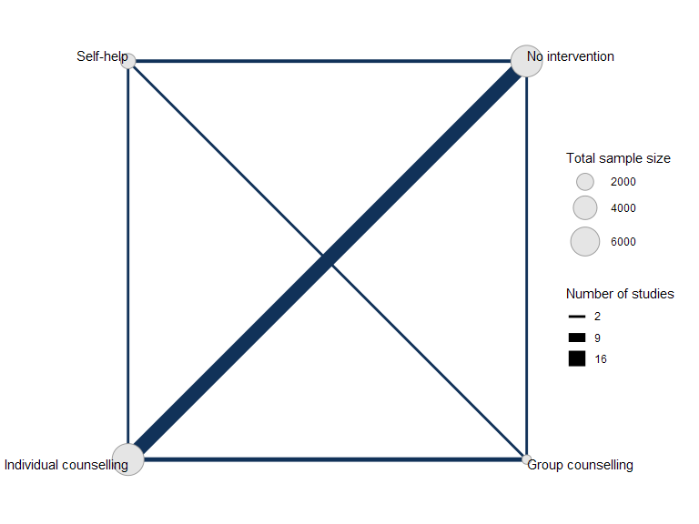

```r
plot(smknet, weight_edges = TRUE, weight_nodes = TRUE)
```

### Random effects NMA

Following TSD 4, we fit a random effects NMA model, using the `nma()` function with `trt_effects = "random"`. We use $\mathrm{N}(0, 100^2)$ prior distributions for the treatment effects $d_k$ and study-specific intercepts $\mu_j$, and a $\textrm{half-N}(5^2)$ prior distribution for the between-study heterogeneity standard deviation $\tau$. We can examine the range of parameter values implied by these prior distributions with the `summary()` method:

```r
summary(normal(scale = 100))
```

```
#> A Normal prior distribution: location = 0, scale = 100.
#> 50% of the prior density lies between -67.45 and 67.45.
#> 95% of the prior density lies between -196 and 196.
```

```r
summary(half_normal(scale = 5))
```

```
#> A half-Normal prior distribution: location = 0, scale = 5.
#> 50% of the prior density lies between 0 and 3.37.
#> 95% of the prior density lies between 0 and 9.8.
```

The model is fitted using the `nma()` function. By default, this will use a Binomial likelihood and a logit link function, auto-detected from the data.

```r
smkfit <- nma(smknet,
              trt_effects = "random",
              prior_intercept = normal(scale = 100),
              prior_trt = normal(scale = 100),
              prior_het = normal(scale = 5))
```

Basic parameter summaries are given by the `print()` method:

```r
smkfit
```

```
#> A random effects NMA with a binomial likelihood (logit link).
#> Inference for Stan model: binomial_1par.
#> 4 chains, each with iter=2000; warmup=1000; thin=1;
#> post-warmup draws per chain=1000, total post-warmup draws=4000.
#>
#>                               mean se_mean   sd     2.5%      25%      50%      75%    97.5% n_eff Rhat
#> d[Group counselling]          1.10    0.01 0.44     0.29     0.81     1.09     1.38     2.00  1552    1
#> d[Individual counselling]     0.86    0.01 0.24     0.42     0.70     0.84     1.01     1.37  1113    1
#> d[Self-help]                  0.49    0.01 0.40    -0.28     0.23     0.48     0.75     1.32  1656    1
#> lp__                      -5767.86    0.20 6.40 -5781.17 -5772.11 -5767.61 -5763.29 -5756.13  1032    1
#> tau                           0.84    0.01 0.19     0.54     0.71     0.82     0.95     1.26  1011    1
#>
#> Samples were drawn using NUTS(diag_e) at Tue Dec 01 17:42:24 2020.
#> For each parameter, n_eff is a crude measure of effective sample size,
#> and Rhat is the potential scale reduction factor on split chains (at
#> convergence, Rhat=1).
```

By default, summaries of the study-specific intercepts $\mu_j$ and study-specific relative effects $\delta_{jk}$ are hidden, but could be examined by changing the `pars` argument:

```r
# Not run
print(smkfit, pars = c("d", "tau", "mu", "delta"))
```

The prior and posterior distributions can be compared visually using the `plot_prior_posterior()` function:

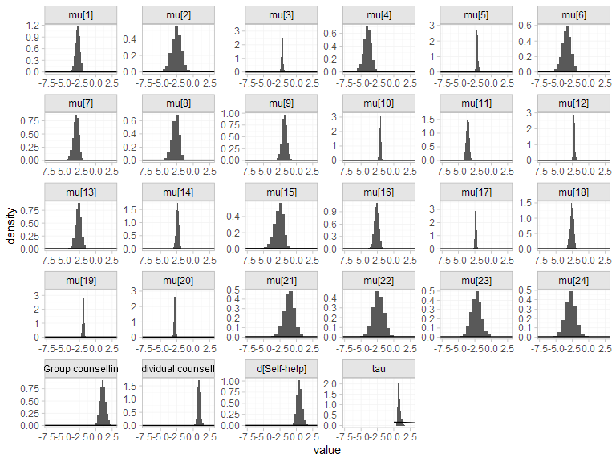

```r
plot_prior_posterior(smkfit)
```

By default, this displays all model parameters given prior distributions (in this case $d_k$, $\mu_j$, and $\tau$), but this may be changed using the `prior` argument:

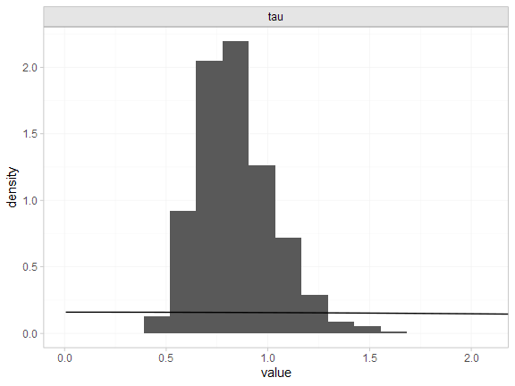

```r
plot_prior_posterior(smkfit, prior = "het")
```

Model fit can be checked using the `dic()` function

```r
(dic_consistency <- dic(smkfit))
```

```
#> Residual deviance: 53.9 (on 50 data points)
#>                pD: 43.7
#>               DIC: 97.6
```

and the residual deviance contributions examined with the corresponding `plot()` method

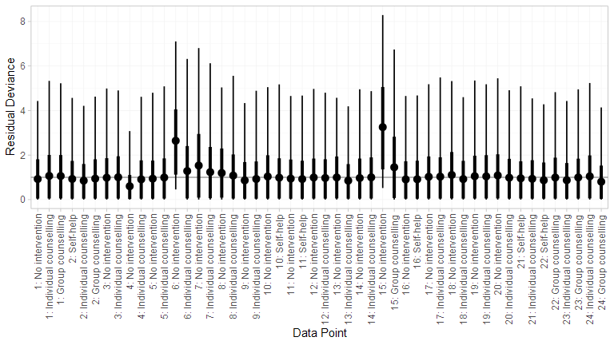

```r
plot(dic_consistency)
```

Overall model fit seems to be adequate, with almost all points showing good fit (mean residual deviance contribution of 1). The only two points with higher residual deviance (i.e. worse fit) correspond to the two zero counts in the data:

```r
smoking[smoking$r == 0, ]
```

```
#>    studyn trtn            trtc r  n
#> 13      6    1 No intervention 0 33
#> 31     15    1 No intervention 0 20
```

### Checking for inconsistency

We fit an unrelated mean effects (UME) model (Dias et al. 2011) to assess the consistency assumption. Again, we use the function `nma()`, but now with the argument `consistency = "ume"`.

```r
smkfit_ume <- nma(smknet,
                  consistency = "ume",
                  trt_effects = "random",
                  prior_intercept = normal(scale = 100),
                  prior_trt = normal(scale = 100),
                  prior_het = normal(scale = 5))
smkfit_ume
```

```
#> A random effects NMA with a binomial likelihood (logit link).
#> An inconsistency model ('ume') was fitted.
#> Inference for Stan model: binomial_1par.
#> 4 chains, each with iter=2000; warmup=1000; thin=1;
#> post-warmup draws per chain=1000, total post-warmup draws=4000.
#>
#>                                                     mean se_mean   sd     2.5%      25%      50%      75%    97.5% n_eff
#> d[Group counselling vs. No intervention]            1.12    0.01 0.79    -0.38     0.60     1.08     1.60     2.77  3205
#> d[Individual counselling vs. No intervention]       0.90    0.01 0.28     0.37     0.71     0.89     1.08     1.50  1094
#> d[Self-help vs. No intervention]                    0.34    0.01 0.58    -0.86    -0.02     0.34     0.72     1.45  2225
#> d[Individual counselling vs. Group counselling]    -0.30    0.01 0.61    -1.49    -0.68    -0.31     0.09     0.95  2491
#> d[Self-help vs. Group counselling]                 -0.61    0.01 0.71    -1.98    -1.08    -0.62    -0.12     0.80  2463
#> d[Self-help vs. Individual counselling]             0.16    0.02 1.04    -1.91    -0.51     0.17     0.84     2.19  3865
#> lp__                                            -5765.28    0.20 6.31 -5778.29 -5769.45 -5764.78 -5760.85 -5754.16   973
#> tau                                                 0.93    0.01 0.22     0.60     0.78     0.90     1.06     1.44  1246
#>                                                 Rhat
#> d[Group counselling vs. No intervention]           1
#> d[Individual counselling vs. No intervention]      1
#> d[Self-help vs. No intervention]                   1
#> d[Individual counselling vs. Group counselling]    1
#> d[Self-help vs. Group counselling]                 1
#> d[Self-help vs. Individual counselling]            1
#> lp__                                               1
#> tau                                                1
#>
#> Samples were drawn using NUTS(diag_e) at Tue Dec 01 17:43:04 2020.
#> For each parameter, n_eff is a crude measure of effective sample size,
#> and Rhat is the potential scale reduction factor on split chains (at
#> convergence, Rhat=1).
```

Comparing the model fit statistics

```r
dic_consistency
```

```
#> Residual deviance: 53.9 (on 50 data points)
#>                pD: 43.7
#>               DIC: 97.6
```

```r
(dic_ume <- dic(smkfit_ume))
```

```
#> Residual deviance: 53.9 (on 50 data points)
#>                pD: 45
#>               DIC: 98.9
```

We see that there is little to choose between the two models. However, it is also important to examine the individual contributions to model fit of each data point under the two models (a so-called “dev-dev” plot). Passing two `nma_dic` objects produced by the `dic()` function to the `plot()` method produces this dev-dev plot:

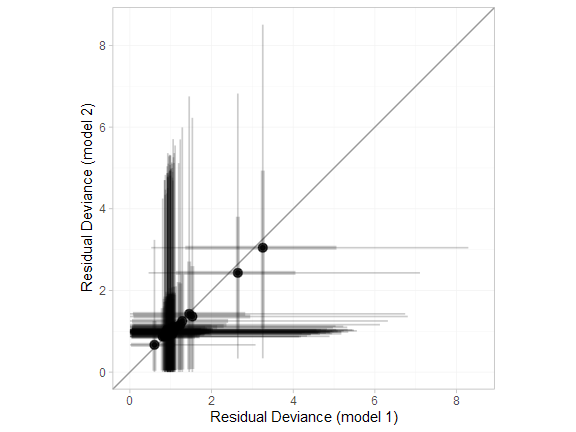

```r
plot(dic_consistency, dic_ume, point_alpha = 0.5, interval_alpha = 0.2)
```

All points lie roughly on the line of equality, so there is no evidence for inconsistency here.

### Further results

Pairwise relative effects, for all pairwise contrasts with `all_contrasts = TRUE`.

```r
(smk_releff <- relative_effects(smkfit, all_contrasts = TRUE))
```

```
#>                                                  mean   sd  2.5%   25%   50%   75% 97.5% Bulk_ESS Tail_ESS Rhat
#> d[Group counselling vs. No intervention]         1.10 0.44  0.29  0.81  1.09  1.38  2.00     1614     1879    1
#> d[Individual counselling vs. No intervention]    0.86 0.24  0.42  0.70  0.84  1.01  1.37     1131     1785    1
#> d[Self-help vs. No intervention]                 0.49 0.40 -0.28  0.23  0.48  0.75  1.32     1646     2047    1
#> d[Individual counselling vs. Group counselling] -0.24 0.41 -1.09 -0.52 -0.23  0.02  0.57     2409     2353    1
#> d[Self-help vs. Group counselling]              -0.61 0.48 -1.58 -0.92 -0.61 -0.30  0.36     2132     2499    1
#> d[Self-help vs. Individual counselling]         -0.37 0.42 -1.20 -0.64 -0.37 -0.10  0.45     1852     2335    1
```

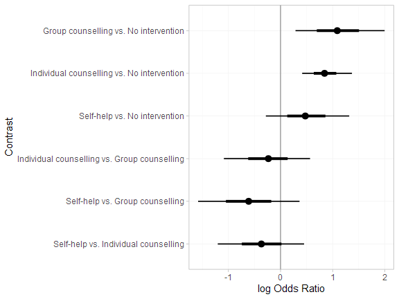

```r
plot(smk_releff, ref_line = 0)
```

Treatment rankings, rank probabilities, and cumulative rank probabilities. We set `lower_better = FALSE` since a higher log odds of cessation is better (the outcome is positive).

```r
(smk_ranks <- posterior_ranks(smkfit, lower_better = FALSE))
```

```
#>                              mean   sd 2.5% 25% 50% 75% 97.5% Bulk_ESS Tail_ESS Rhat
#> rank[No intervention]        3.89 0.31    3   4   4   4     4     2297       NA    1
#> rank[Group counselling]      1.37 0.62    1   1   1   2     3     2897     3013    1
#> rank[Individual counselling] 1.91 0.62    1   2   2   2     3     2406       NA    1
#> rank[Self-help]              2.83 0.68    1   3   3   3     4     2017       NA    1
```

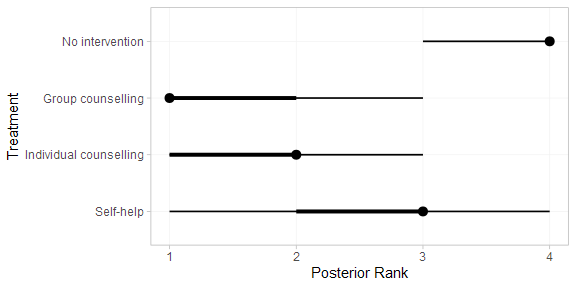

```r
plot(smk_ranks)
```

```r
(smk_rankprobs <- posterior_rank_probs(smkfit, lower_better = FALSE))
```

```
#>                           p_rank[1] p_rank[2] p_rank[3] p_rank[4]
#> d[No intervention]             0.00      0.00      0.10      0.89
#> d[Group counselling]           0.70      0.23      0.07      0.00
#> d[Individual counselling]      0.24      0.60      0.15      0.00
#> d[Self-help]                   0.06      0.17      0.68      0.10
```

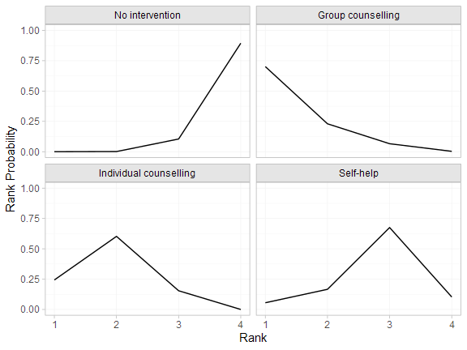

```r
plot(smk_rankprobs)
```

```r
(smk_cumrankprobs <- posterior_rank_probs(smkfit, lower_better = FALSE, cumulative = TRUE))
```

```
#>                           p_rank[1] p_rank[2] p_rank[3] p_rank[4]
#> d[No intervention]             0.00      0.00      0.11         1
#> d[Group counselling]           0.70      0.93      1.00         1
#> d[Individual counselling]      0.24      0.85      1.00         1
#> d[Self-help]                   0.06      0.22      0.90         1
```

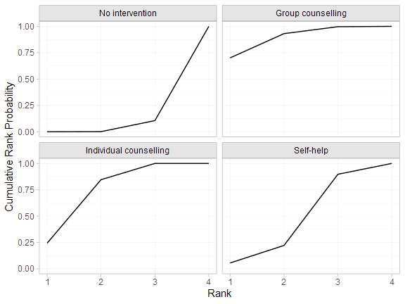

```r
plot(smk_cumrankprobs)
```

## References

Dias, S., N. J. Welton, A. J. Sutton, D. M. Caldwell, G. Lu, and A. E. Ades. 2011. “NICE DSU Technical Support Document 4: Inconsistency in Networks of Evidence Based on Randomised Controlled Trials.” National Institute for Health and Care Excellence. http://nicedsu.org.uk/.

Hasselblad, V. 1998. “Meta-Analysis of Multitreatment Studies.” *Medical Decision Making* 18 (1): 37–43. https://doi.org/10.1177/0272989x9801800110.